# Business Case: Delhivery - Feature Engineering

[figure not shown]

### Delhivery is the largest and fastest-growing fully integrated player in India by revenue in Fiscal 2021. They aim to build the operating system for commerce, through a combination of world-class infrastructure, logistics operations of the highest quality, and cutting-edge engineering and technology capabilities.

### The Data team builds intelligence and capabilities using this data that helps them to widen the gap between the quality, efficiency, and profitability of their business versus their competitors.

## Tasks at hand

How can you help here?

The company wants to understand and process the data coming out of data engineering pipelines:

• Clean, sanitize and manipulate data to get useful features out of raw fields

• Make sense out of the raw data and help the data science team to build forecasting models on it

```python
import pandas as pd
import numpy as np
from matplotlib import pyplot as plt
import seaborn as sns
import scipy.stats as spy
from datetime import datetime, timedelta
print("Setup Complete!")
```

```
Setup Complete!
```

```python
delhivery_df = pd.read_csv(r"D:\DSML\Case Studies\Delhivery Use Case\delhivery_data.txt")
```

```python
delhivery_df.head(5)
```

|  | data | trip_creation_time | route_schedule_uuid | route_type | trip_uuid | source_center | source_name | destination_center | destination_name | od_start_time | ... | cutoff_timestamp | actual_distance_to_destination | actual_time | osrm_time | osrm_distance | factor | segment_actual_time | segment_osrm_time | segment_osrm_distance | segment_factor |
| --- | --- | --- | --- | --- | --- | --- | --- | --- | --- | --- | --- | --- | --- | --- | --- | --- | --- | --- | --- | --- | --- |
| 0 | training | 2018-09-20 02:35:36.476840 | thanos::sroute:eb7bfc78-b351-4c0e-a951-fa3d5c3... | Carting | trip-153741093647649320 | IND388121AAA | Anand_VUNagar_DC (Gujarat) | IND388620AAB | Khambhat_MotvdDPP_D (Gujarat) | 2018-09-20 03:21:32.418600 | ... | 2018-09-20 04:27:55 | 10.435660 | 14.0 | 11.0 | 11.9653 | 1.272727 | 14.0 | 11.0 | 11.9653 | 1.272727 |
| 1 | training | 2018-09-20 02:35:36.476840 | thanos::sroute:eb7bfc78-b351-4c0e-a951-fa3d5c3... | Carting | trip-153741093647649320 | IND388121AAA | Anand_VUNagar_DC (Gujarat) | IND388620AAB | Khambhat_MotvdDPP_D (Gujarat) | 2018-09-20 03:21:32.418600 | ... | 2018-09-20 04:17:55 | 18.936842 | 24.0 | 20.0 | 21.7243 | 1.200000 | 10.0 | 9.0 | 9.7590 | 1.111111 |
| 2 | training | 2018-09-20 02:35:36.476840 | thanos::sroute:eb7bfc78-b351-4c0e-a951-fa3d5c3... | Carting | trip-153741093647649320 | IND388121AAA | Anand_VUNagar_DC (Gujarat) | IND388620AAB | Khambhat_MotvdDPP_D (Gujarat) | 2018-09-20 03:21:32.418600 | ... | 2018-09-20 04:01:19.505586 | 27.637279 | 40.0 | 28.0 | 32.5395 | 1.428571 | 16.0 | 7.0 | 10.8152 | 2.285714 |
| 3 | training | 2018-09-20 02:35:36.476840 | thanos::sroute:eb7bfc78-b351-4c0e-a951-fa3d5c3... | Carting | trip-153741093647649320 | IND388121AAA | Anand_VUNagar_DC (Gujarat) | IND388620AAB | Khambhat_MotvdDPP_D (Gujarat) | 2018-09-20 03:21:32.418600 | ... | 2018-09-20 03:39:57 | 36.118028 | 62.0 | 40.0 | 45.5620 | 1.550000 | 21.0 | 12.0 | 13.0224 | 1.750000 |
| 4 | training | 2018-09-20 02:35:36.476840 | thanos::sroute:eb7bfc78-b351-4c0e-a951-fa3d5c3... | Carting | trip-153741093647649320 | IND388121AAA | Anand_VUNagar_DC (Gujarat) | IND388620AAB | Khambhat_MotvdDPP_D (Gujarat) | 2018-09-20 03:21:32.418600 | ... | 2018-09-20 03:33:55 | 39.386040 | 68.0 | 44.0 | 54.2181 | 1.545455 | 6.0 | 5.0 | 3.9153 | 1.200000 |

5 rows × 24 columns

```python
delhivery_df.shape
```

```
(144867, 24)
```

### Observation

- we have a data with 24 columns and 144867 rows

```python
delhivery_df.columns
```

```
Index(['data', 'trip_creation_time', 'route_schedule_uuid', 'route_type',
       'trip_uuid', 'source_center', 'source_name', 'destination_center',
       'destination_name', 'od_start_time', 'od_end_time',
       'start_scan_to_end_scan', 'is_cutoff', 'cutoff_factor',
       'cutoff_timestamp', 'actual_distance_to_destination', 'actual_time',
       'osrm_time', 'osrm_distance', 'factor', 'segment_actual_time',
       'segment_osrm_time', 'segment_osrm_distance', 'segment_factor'],
      dtype='object')
```

```python
delhivery_df.dtypes
```

```
data                               object
trip_creation_time                 object
route_schedule_uuid                object
route_type                         object
trip_uuid                          object
source_center                      object
source_name                        object
destination_center                 object
destination_name                   object
od_start_time                      object
od_end_time                        object
start_scan_to_end_scan            float64
is_cutoff                            bool
cutoff_factor                       int64
cutoff_timestamp                   object
actual_distance_to_destination    float64
actual_time                       float64
osrm_time                         float64
osrm_distance                     float64
factor                            float64
segment_actual_time               float64
segment_osrm_time                 float64
segment_osrm_distance             float64
segment_factor                    float64
dtype: object
```

```python
delhivery_df.info()
```

```
<class 'pandas.core.frame.DataFrame'>
RangeIndex: 144867 entries, 0 to 144866
Data columns (total 24 columns):
 #   Column                          Non-Null Count   Dtype
---  ------                          --------------   -----
 0   data                            144867 non-null  object
 1   trip_creation_time              144867 non-null  object
 2   route_schedule_uuid             144867 non-null  object
 3   route_type                      144867 non-null  object
 4   trip_uuid                       144867 non-null  object
 5   source_center                   144867 non-null  object
 6   source_name                     144574 non-null  object
 7   destination_center              144867 non-null  object
 8   destination_name                144606 non-null  object
 9   od_start_time                   144867 non-null  object
```

[output cut: 16 more lines]

### Observation

- Data is using slightly more memory with float 64, if we can check the details for max and min we could optimize this

```python
unknow_fields = ['is_cutoff','cutoff_factor','cutoff_timestamp','factor','segment_factor']

delhivery_df = delhivery_df.drop(columns = unknow_fields)
```

```python
delhivery_df.shape
```

```
(144867, 19)
```

```python
for column in delhivery_df.columns:
    print(f" Unique Entries for the {column:<30} column is {delhivery_df[column].nunique()} ")
```

```
 Unique Entries for the data                           column is 2
 Unique Entries for the trip_creation_time             column is 14817
 Unique Entries for the route_schedule_uuid            column is 1504
 Unique Entries for the route_type                     column is 2
 Unique Entries for the trip_uuid                      column is 14817
 Unique Entries for the source_center                  column is 1508
 Unique Entries for the source_name                    column is 1498
 Unique Entries for the destination_center             column is 1481
 Unique Entries for the destination_name               column is 1468
 Unique Entries for the od_start_time                  column is 26369
 Unique Entries for the od_end_time                    column is 26369
 Unique Entries for the start_scan_to_end_scan         column is 1915
 Unique Entries for the actual_distance_to_destination column is 144515
 Unique Entries for the actual_time                    column is 3182
 Unique Entries for the osrm_time                      column is 1531
 Unique Entries for the osrm_distance                  column is 138046
 Unique Entries for the segment_actual_time            column is 747
 Unique Entries for the segment_osrm_time              column is 214
 Unique Entries for the segment_osrm_distance          column is 113799
```

```python
delhivery_df['data'] = delhivery_df['data'].astype('category')
delhivery_df['route_type'] = delhivery_df['route_type'].astype('category')
```

```python
floating_columns = ['actual_distance_to_destination','actual_time','osrm_time','osrm_distance','segment_actual_time','segment_osrm_time','segment_osrm_distance']
for col in floating_columns:
    print(delhivery_df[col].max())
```

```
1927.4477046975032
4532.0
1686.0
2326.1991000000003
3051.0
1611.0
2191.4037000000003
```

```python
for col in floating_columns:
    delhivery_df[col] = delhivery_df[col].astype('float32')
```

```python
datetime_columns = ['trip_creation_time','od_start_time','od_end_time']
for col in datetime_columns:
    delhivery_df[col] = pd.to_datetime(delhivery_df[col])
```

```python
delhivery_df.info()
```

```
<class 'pandas.core.frame.DataFrame'>
RangeIndex: 144867 entries, 0 to 144866
Data columns (total 19 columns):
 #   Column                          Non-Null Count   Dtype
---  ------                          --------------   -----
 0   data                            144867 non-null  category
 1   trip_creation_time              144867 non-null  datetime64[ns]
 2   route_schedule_uuid             144867 non-null  object
 3   route_type                      144867 non-null  category
 4   trip_uuid                       144867 non-null  object
 5   source_center                   144867 non-null  object
 6   source_name                     144574 non-null  object
 7   destination_center              144867 non-null  object
 8   destination_name                144606 non-null  object
 9   od_start_time                   144867 non-null  datetime64[ns]
 10  od_end_time                     144867 non-null  datetime64[ns]
 11  start_scan_to_end_scan          144867 non-null  float64
 12  actual_distance_to_destination  144867 non-null  float32
 13  actual_time                     144867 non-null  float32
 14  osrm_time                       144867 non-null  float32
 15  osrm_distance                   144867 non-null  float32
 16  segment_actual_time             144867 non-null  float32
 17  segment_osrm_time               144867 non-null  float32
 18  segment_osrm_distance           144867 non-null  float32
dtypes: category(2), datetime64[ns](3), float32(7), float64(1), object(6)
memory usage: 15.2+ MB
```

### Observation

- as we converted the data to float 32 and datetime to correct range and type it is now a little optimized

```python
delhivery_df['trip_creation_time'].min() , delhivery_df['od_end_time'].max()
```

```
(Timestamp('2018-09-12 00:00:16.535741'),
 Timestamp('2018-10-08 03:00:24.353479'))
```

```python
np.any(delhivery_df.isnull())
```

```
True
```

```python
delhivery_df.isnull().sum()
```

```
data                                0
trip_creation_time                  0
route_schedule_uuid                 0
route_type                          0
trip_uuid                           0
source_center                       0
source_name                       293
destination_center                  0
destination_name                  261
od_start_time                       0
od_end_time                         0
start_scan_to_end_scan              0
actual_distance_to_destination      0
actual_time                         0
osrm_time                           0
osrm_distance                       0
segment_actual_time                 0
segment_osrm_time                   0
segment_osrm_distance               0
dtype: int64
```

### Observation

- source_name and and destination_name has null values in them

```python
missing_source_name = delhivery_df.loc[delhivery_df['source_name'].isnull(), 'source_center'].unique()
missing_source_name
```

```
array(['IND342902A1B', 'IND577116AAA', 'IND282002AAD', 'IND465333A1B',
       'IND841301AAC', 'IND509103AAC', 'IND126116AAA', 'IND331022A1B',
       'IND505326AAB', 'IND852118A1B'], dtype=object)
```

```python
for col in missing_source_name:
    uniq_sname = delhivery_df.loc[delhivery_df['source_center'] == col, 'source_name'].unique()
    if pd.isna(uniq_sname):
        print(f'Source Center is:-> {col} ----------> Source Name is:-> Not Found')
    else:
        print(f'Source Center is:-> {col} ----------> Source Name is:-> {uniq_sname}')
```

```
Source Center is:-> IND342902A1B ----------> Source Name is:-> Not Found
Source Center is:-> IND577116AAA ----------> Source Name is:-> Not Found
Source Center is:-> IND282002AAD ----------> Source Name is:-> Not Found
Source Center is:-> IND465333A1B ----------> Source Name is:-> Not Found
Source Center is:-> IND841301AAC ----------> Source Name is:-> Not Found
Source Center is:-> IND509103AAC ----------> Source Name is:-> Not Found
Source Center is:-> IND126116AAA ----------> Source Name is:-> Not Found
Source Center is:-> IND331022A1B ----------> Source Name is:-> Not Found
Source Center is:-> IND505326AAB ----------> Source Name is:-> Not Found
Source Center is:-> IND852118A1B ----------> Source Name is:-> Not Found
```

```python
for i in missing_source_name:
    unique_destination_name = delhivery_df.loc[delhivery_df['destination_center'] == i, 'destination_name'].unique()
    if (pd.isna(uniq_sname)) or (uniq_sname.size == 0):
        print("Destination Center :", i, "-" * 10, "Destination Name :", 'Not Found')
    else :
        print("Destination Center :", i, "-" * 10, "Destination Name :", unique_destination_name)
```

```
Destination Center : IND342902A1B ---------- Destination Name : Not Found
Destination Center : IND577116AAA ---------- Destination Name : Not Found
Destination Center : IND282002AAD ---------- Destination Name : Not Found
Destination Center : IND465333A1B ---------- Destination Name : Not Found
Destination Center : IND841301AAC ---------- Destination Name : Not Found
Destination Center : IND509103AAC ---------- Destination Name : Not Found
Destination Center : IND126116AAA ---------- Destination Name : Not Found
Destination Center : IND331022A1B ---------- Destination Name : Not Found
Destination Center : IND505326AAB ---------- Destination Name : Not Found
Destination Center : IND852118A1B ---------- Destination Name : Not Found
```

```python
missing_destination_name = delhivery_df.loc[delhivery_df['destination_name'].isnull(), 'destination_center'].unique()
missing_destination_name
```

```
array(['IND342902A1B', 'IND577116AAA', 'IND282002AAD', 'IND465333A1B',
       'IND841301AAC', 'IND505326AAB', 'IND852118A1B', 'IND126116AAA',
       'IND509103AAC', 'IND221005A1A', 'IND250002AAC', 'IND331001A1C',
       'IND122015AAC'], dtype=object)
```

```python
np.all(delhivery_df.loc[delhivery_df['source_name'].isnull(), 'source_center'].isin(missing_destination_name))
```

```
False
```

```python
counter = 1
for i in missing_destination_name:
    delhivery_df.loc[delhivery_df['destination_center'] == i, 'destination_name'] = delhivery_df.loc[delhivery_df['destination_center'] == i, 'destination_name'].replace(np.nan, f'location_{counter}')
    counter += 1
```

```python
data_dict = {}
for i in missing_source_name:
    data_dict[i] = delhivery_df.loc[delhivery_df['destination_center'] == i, 'destination_name'].unique()
for idx, val in data_dict.items():
    if len(val) == 0:
        data_dict[idx] = [f'location_{counter}']
        counter += 1
d2 = {}
for idx, val in data_dict.items():
    d2[idx] = val[0]
for i, v in d2.items():
    print(i, v)
```

```
IND342902A1B location_1
IND577116AAA location_2
IND282002AAD location_3
IND465333A1B location_4
IND841301AAC location_5
IND509103AAC location_9
IND126116AAA location_8
IND331022A1B location_14
IND505326AAB location_6
IND852118A1B location_7
```

```python
for i in missing_source_name:
    delhivery_df.loc[delhivery_df['source_center'] == i, 'source_name'] = delhivery_df.loc[delhivery_df['source_center'] == i, 'source_name'].replace(np.nan, d2[i])
```

```python
delhivery_df.isna().sum()
```

```
data                              0
trip_creation_time                0
route_schedule_uuid               0
route_type                        0
trip_uuid                         0
source_center                     0
source_name                       0
destination_center                0
destination_name                  0
od_start_time                     0
od_end_time                       0
start_scan_to_end_scan            0
actual_distance_to_destination    0
actual_time                       0
osrm_time                         0
osrm_distance                     0
segment_actual_time               0
segment_osrm_time                 0
segment_osrm_distance             0
dtype: int64
```

### Observation

- after matching the details for missing data with respect to source_center with source_name ad destination_center with destination_center we are able to fill it all

```python
delhivery_df.describe()
```

|  | trip_creation_time | od_start_time | od_end_time | start_scan_to_end_scan | actual_distance_to_destination | actual_time | osrm_time | osrm_distance | segment_actual_time | segment_osrm_time | segment_osrm_distance |
| --- | --- | --- | --- | --- | --- | --- | --- | --- | --- | --- | --- |
| count | 144867 | 144867 | 144867 | 144867.000000 | 144867.000000 | 144867.000000 | 144867.000000 | 144867.000000 | 144867.000000 | 144867.000000 | 144867.000000 |
| mean | 2018-09-22 13:34:23.659819264 | 2018-09-22 18:02:45.855230720 | 2018-09-23 10:04:31.395393024 | 961.262986 | 234.073380 | 416.927521 | 213.868286 | 284.771301 | 36.196110 | 18.507547 | 22.829018 |
| min | 2018-09-12 00:00:16.535741 | 2018-09-12 00:00:16.535741 | 2018-09-12 00:50:10.814399 | 20.000000 | 9.000046 | 9.000000 | 6.000000 | 9.008200 | -244.000000 | 0.000000 | 0.000000 |
| 25% | 2018-09-17 03:20:51.775845888 | 2018-09-17 08:05:40.886155008 | 2018-09-18 01:48:06.410121984 | 161.000000 | 23.355875 | 51.000000 | 27.000000 | 29.914701 | 20.000000 | 11.000000 | 12.070100 |
| 50% | 2018-09-22 04:24:27.932764928 | 2018-09-22 08:53:00.116656128 | 2018-09-23 03:13:03.520212992 | 449.000000 | 66.126572 | 132.000000 | 64.000000 | 78.525803 | 29.000000 | 17.000000 | 23.513000 |
| 75% | 2018-09-27 17:57:56.350054912 | 2018-09-27 22:41:50.285857024 | 2018-09-28 12:49:06.054018048 | 1634.000000 | 286.708878 | 513.000000 | 257.000000 | 343.193253 | 40.000000 | 22.000000 | 27.813250 |
| max | 2018-10-03 23:59:42.701692 | 2018-10-06 04:27:23.392375 | 2018-10-08 03:00:24.353479 | 7898.000000 | 1927.447754 | 4532.000000 | 1686.000000 | 2326.199219 | 3051.000000 | 1611.000000 | 2191.403809 |
| std | NaN | NaN | NaN | 1037.012769 | 344.990021 | 598.103638 | 308.011078 | 421.119293 | 53.571156 | 14.775960 | 17.860661 |

```python
delhivery_df.describe(include='object')
```

|  | route_schedule_uuid | trip_uuid | source_center | source_name | destination_center | destination_name |
| --- | --- | --- | --- | --- | --- | --- |
| count | 144867 | 144867 | 144867 | 144867 | 144867 | 144867 |
| unique | 1504 | 14817 | 1508 | 1508 | 1481 | 1481 |
| top | thanos::sroute:4029a8a2-6c74-4b7e-a6d8-f9e069f... | trip-153811219535896559 | IND000000ACB | Gurgaon_Bilaspur_HB (Haryana) | IND000000ACB | Gurgaon_Bilaspur_HB (Haryana) |
| freq | 1812 | 101 | 23347 | 23347 | 15192 | 15192 |

```python
grouping_1 = ['trip_uuid', 'source_center', 'destination_center']
delhivery_df_grouped = delhivery_df.groupby(by = grouping_1, as_index = False).agg({'data' : 'first','route_type' : 'first','trip_creation_time' : 'first','source_name' : 'first','destination_name' : 'last',
                                                       'od_start_time' : 'first','od_end_time' : 'first','start_scan_to_end_scan' : 'first','actual_distance_to_destination' : 'last',
                                                       'actual_time' : 'last','osrm_time' : 'last','osrm_distance' : 'last','segment_actual_time' : 'sum','segment_osrm_time' : 'sum',
                                                       'segment_osrm_distance' : 'sum'})
```

```python
delhivery_df_grouped
```

|  | trip_uuid | source_center | destination_center | data | route_type | trip_creation_time | source_name | destination_name | od_start_time | od_end_time | start_scan_to_end_scan | actual_distance_to_destination | actual_time | osrm_time | osrm_distance | segment_actual_time | segment_osrm_time | segment_osrm_distance |
| --- | --- | --- | --- | --- | --- | --- | --- | --- | --- | --- | --- | --- | --- | --- | --- | --- | --- | --- |
| 0 | trip-153671041653548748 | IND209304AAA | IND000000ACB | training | FTL | 2018-09-12 00:00:16.535741 | Kanpur_Central_H_6 (Uttar Pradesh) | Gurgaon_Bilaspur_HB (Haryana) | 2018-09-12 16:39:46.858469 | 2018-09-13 13:40:23.123744 | 1260.0 | 383.759155 | 732.0 | 329.0 | 446.549591 | 728.0 | 534.0 | 670.620483 |
| 1 | trip-153671041653548748 | IND462022AAA | IND209304AAA | training | FTL | 2018-09-12 00:00:16.535741 | Bhopal_Trnsport_H (Madhya Pradesh) | Kanpur_Central_H_6 (Uttar Pradesh) | 2018-09-12 00:00:16.535741 | 2018-09-12 16:39:46.858469 | 999.0 | 440.973694 | 830.0 | 388.0 | 544.802673 | 820.0 | 474.0 | 649.852783 |
| 2 | trip-153671042288605164 | IND561203AAB | IND562101AAA | training | Carting | 2018-09-12 00:00:22.886430 | Doddablpur_ChikaDPP_D (Karnataka) | Chikblapur_ShntiSgr_D (Karnataka) | 2018-09-12 02:03:09.655591 | 2018-09-12 03:01:59.598855 | 58.0 | 24.644020 | 47.0 | 26.0 | 28.199400 | 46.0 | 26.0 | 28.199501 |
| 3 | trip-153671042288605164 | IND572101AAA | IND561203AAB | training | Carting | 2018-09-12 00:00:22.886430 | Tumkur_Veersagr_I (Karnataka) | Doddablpur_ChikaDPP_D (Karnataka) | 2018-09-12 00:00:22.886430 | 2018-09-12 02:03:09.655591 | 122.0 | 48.542889 | 96.0 | 42.0 | 56.911598 | 95.0 | 39.0 | 55.989899 |
| 4 | trip-153671043369099517 | IND000000ACB | IND160002AAC | training | FTL | 2018-09-12 00:00:33.691250 | Gurgaon_Bilaspur_HB (Haryana) | Chandigarh_Mehmdpur_H (Punjab) | 2018-09-14 03:40:17.106733 | 2018-09-14 17:34:55.442454 | 834.0 | 237.439606 | 611.0 | 212.0 | 281.210907 | 608.0 | 231.0 | 317.740784 |
| ... | ... | ... | ... | ... | ... | ... | ... | ... | ... | ... | ... | ... | ... | ... | ... | ... | ... | ... |
| 26363 | trip-153861115439069069 | IND628204AAA | IND627657AAA | test | Carting | 2018-10-03 23:59:14.390954 | Tirchchndr_Shnmgprm_D (Tamil Nadu) | Thisayanvilai_UdnkdiRD_D (Tamil Nadu) | 2018-10-04 02:29:04.272194 | 2018-10-04 03:31:11.183797 | 62.0 | 33.627182 | 51.0 | 41.0 | 42.521301 | 49.0 | 42.0 | 42.143101 |
| 26364 | trip-153861115439069069 | IND628613AAA | IND627005AAA | test | Carting | 2018-10-03 23:59:14.390954 | Peikulam_SriVnktpm_D (Tamil Nadu) | Tirunelveli_VdkkuSrt_I (Tamil Nadu) | 2018-10-04 04:16:39.894872 | 2018-10-04 05:47:45.162682 | 91.0 | 33.673836 | 90.0 | 48.0 | 40.608002 | 89.0 | 77.0 | 78.586899 |
| 26365 | trip-153861115439069069 | IND628801AAA | IND628204AAA | test | Carting | 2018-10-03 23:59:14.390954 | Eral_Busstand_D (Tamil Nadu) | Tirchchndr_Shnmgprm_D (Tamil Nadu) | 2018-10-04 01:44:53.808000 | 2018-10-04 02:29:04.272194 | 44.0 | 12.661944 | 30.0 | 14.0 | 16.018499 | 29.0 | 14.0 | 16.018400 |
| 26366 | trip-153861118270144424 | IND583119AAA | IND583101AAA | test | FTL | 2018-10-03 23:59:42.701692 | Sandur_WrdN1DPP_D (Karnataka) | Bellary_Dc (Karnataka) | 2018-10-04 03:58:40.726547 | 2018-10-04 08:46:09.166940 | 287.0 | 40.546738 | 233.0 | 42.0 | 52.530300 | 233.0 | 42.0 | 52.530300 |
| 26367 | trip-153861118270144424 | IND583201AAA | IND583119AAA | test | FTL | 2018-10-03 23:59:42.701692 | Hospet (Karnataka) | Sandur_WrdN1DPP_D (Karnataka) | 2018-10-04 02:51:44.712656 | 2018-10-04 03:58:40.726547 | 66.0 | 25.534794 | 42.0 | 26.0 | 28.048401 | 41.0 | 25.0 | 28.048401 |

26368 rows × 18 columns

```python
delhivery_df_grouped['od_total_time'] = delhivery_df_grouped['od_end_time'] - delhivery_df_grouped['od_start_time']
delhivery_df_grouped.drop(columns = ['od_end_time', 'od_start_time'], inplace = True)
delhivery_df_grouped['od_total_time'] = delhivery_df_grouped['od_total_time'].apply(lambda x : round(x.total_seconds() / 60.0, 2))
delhivery_df_grouped['od_total_time'].head()
```

```
0    1260.60
1     999.51
2      58.83
3     122.78
4     834.64
Name: od_total_time, dtype: float64
```

```python
delhivery_df_group_tripid = delhivery_df_grouped.groupby(by = 'trip_uuid', as_index = False).agg({'source_center' : 'first','destination_center' : 'last','data' : 'first','route_type' : 'first','trip_creation_time' : 'first',
                                                           'source_name' : 'first','destination_name' : 'last','od_total_time' : 'sum','start_scan_to_end_scan' : 'sum',
                                                           'actual_distance_to_destination' : 'sum','actual_time' : 'sum','osrm_time' : 'sum','osrm_distance' : 'sum',
                                                           'segment_actual_time' : 'sum','segment_osrm_time' : 'sum','segment_osrm_distance' : 'sum'})
delhivery_df_group_tripid
```

|  | trip_uuid | source_center | destination_center | data | route_type | trip_creation_time | source_name | destination_name | od_total_time | start_scan_to_end_scan | actual_distance_to_destination | actual_time | osrm_time | osrm_distance | segment_actual_time | segment_osrm_time | segment_osrm_distance |
| --- | --- | --- | --- | --- | --- | --- | --- | --- | --- | --- | --- | --- | --- | --- | --- | --- | --- |
| 0 | trip-153671041653548748 | IND209304AAA | IND209304AAA | training | FTL | 2018-09-12 00:00:16.535741 | Kanpur_Central_H_6 (Uttar Pradesh) | Kanpur_Central_H_6 (Uttar Pradesh) | 2260.11 | 2259.0 | 824.732849 | 1562.0 | 717.0 | 991.352295 | 1548.0 | 1008.0 | 1320.473267 |
| 1 | trip-153671042288605164 | IND561203AAB | IND561203AAB | training | Carting | 2018-09-12 00:00:22.886430 | Doddablpur_ChikaDPP_D (Karnataka) | Doddablpur_ChikaDPP_D (Karnataka) | 181.61 | 180.0 | 73.186905 | 143.0 | 68.0 | 85.111000 | 141.0 | 65.0 | 84.189400 |
| 2 | trip-153671043369099517 | IND000000ACB | IND000000ACB | training | FTL | 2018-09-12 00:00:33.691250 | Gurgaon_Bilaspur_HB (Haryana) | Gurgaon_Bilaspur_HB (Haryana) | 3934.36 | 3933.0 | 1927.404297 | 3347.0 | 1740.0 | 2354.066650 | 3308.0 | 1941.0 | 2545.267822 |
| 3 | trip-153671046011330457 | IND400072AAB | IND401104AAA | training | Carting | 2018-09-12 00:01:00.113710 | Mumbai Hub (Maharashtra) | Mumbai_MiraRd_IP (Maharashtra) | 100.49 | 100.0 | 17.175274 | 59.0 | 15.0 | 19.680000 | 59.0 | 16.0 | 19.876600 |
| 4 | trip-153671052974046625 | IND583101AAA | IND583119AAA | training | FTL | 2018-09-12 00:02:09.740725 | Bellary_Dc (Karnataka) | Sandur_WrdN1DPP_D (Karnataka) | 718.34 | 717.0 | 127.448502 | 341.0 | 117.0 | 146.791794 | 340.0 | 115.0 | 146.791901 |
| ... | ... | ... | ... | ... | ... | ... | ... | ... | ... | ... | ... | ... | ... | ... | ... | ... | ... |
| 14812 | trip-153861095625827784 | IND160002AAC | IND160002AAC | test | Carting | 2018-10-03 23:55:56.258533 | Chandigarh_Mehmdpur_H (Punjab) | Chandigarh_Mehmdpur_H (Punjab) | 258.03 | 257.0 | 57.762333 | 83.0 | 62.0 | 73.462997 | 82.0 | 62.0 | 64.855103 |
| 14813 | trip-153861104386292051 | IND121004AAB | IND121004AAA | test | Carting | 2018-10-03 23:57:23.863155 | FBD_Balabhgarh_DPC (Haryana) | Faridabad_Blbgarh_DC (Haryana) | 60.59 | 60.0 | 15.513784 | 21.0 | 12.0 | 16.088200 | 21.0 | 11.0 | 16.088299 |
| 14814 | trip-153861106442901555 | IND208006AAA | IND208006AAA | test | Carting | 2018-10-03 23:57:44.429324 | Kanpur_GovndNgr_DC (Uttar Pradesh) | Kanpur_GovndNgr_DC (Uttar Pradesh) | 422.12 | 421.0 | 38.684837 | 282.0 | 48.0 | 58.903702 | 281.0 | 88.0 | 104.886597 |
| 14815 | trip-153861115439069069 | IND627005AAA | IND628204AAA | test | Carting | 2018-10-03 23:59:14.390954 | Tirunelveli_VdkkuSrt_I (Tamil Nadu) | Tirchchndr_Shnmgprm_D (Tamil Nadu) | 348.52 | 347.0 | 134.723831 | 264.0 | 179.0 | 171.110306 | 258.0 | 221.0 | 223.532394 |
| 14816 | trip-153861118270144424 | IND583119AAA | IND583119AAA | test | FTL | 2018-10-03 23:59:42.701692 | Sandur_WrdN1DPP_D (Karnataka) | Sandur_WrdN1DPP_D (Karnataka) | 354.40 | 353.0 | 66.081528 | 275.0 | 68.0 | 80.578705 | 274.0 | 67.0 | 80.578705 |

14817 rows × 17 columns

```python
def location_name_to_state(x):
    l = x.split('(')
    if len(l) == 1:
        return l[0]
    else:
        return l[1].replace(')', "")
```

```python
def location_name_to_city(x):
    if 'location' in x:
        return 'unknown_city'
    else:
        l = x.split()[0].split('_')
        if 'CCU' in x:
            return 'Kolkata'
        elif 'MAA' in x.upper():
            return 'Chennai'
        elif ('HBR' in x.upper()) or ('BLR' in x.upper()):
            return 'Bengaluru'
        elif 'FBD' in x.upper():
            return 'Faridabad'
        elif 'BOM' in x.upper():
            return 'Mumbai'
        elif 'DEL' in x.upper():
            return 'Delhi'
        elif 'OK' in x.upper():
            return 'Delhi'
        elif 'GZB' in x.upper():
            return 'Ghaziabad'
        elif 'GGN' in x.upper():
            return 'Gurgaon'
        elif 'AMD' in x.upper():
            return 'Ahmedabad'
        elif 'CJB' in x.upper():
            return 'Coimbatore'
        elif 'HYD' in x.upper():
            return 'Hyderabad'
        return l[0]
```

```python
def location_name_to_place(x):
    if 'location' in x:
        return x
    elif 'HBR' in x:
        return 'HBR Layout PC'
    else:
        l = x.split()[0].split('_', 1)
        if len(l) == 1:
            return 'unknown_place'
        else:
            return l[1]
```

```python
delhivery_df_group_tripid['source_state'] = delhivery_df_group_tripid['source_name'].apply(location_name_to_state)
delhivery_df_group_tripid['source_state'].unique()
```

```
array(['Uttar Pradesh', 'Karnataka', 'Haryana', 'Maharashtra',
       'Tamil Nadu', 'Gujarat', 'Delhi', 'Telangana', 'Rajasthan',
       'Assam', 'Madhya Pradesh', 'West Bengal', 'Andhra Pradesh',
       'Punjab', 'Chandigarh', 'Goa', 'Jharkhand', 'Pondicherry',
       'Orissa', 'Uttarakhand', 'Himachal Pradesh', 'Kerala',
       'Arunachal Pradesh', 'Bihar', 'Chhattisgarh',
       'Dadra and Nagar Haveli', 'Jammu & Kashmir', 'Mizoram', 'Nagaland',
       'location_9', 'location_3', 'location_2', 'location_14',
       'location_7'], dtype=object)
```

```python
delhivery_df_group_tripid['source_city'] = delhivery_df_group_tripid['source_name'].apply(location_name_to_city)
print('No of source cities :', delhivery_df_group_tripid['source_city'].nunique())
delhivery_df_group_tripid['source_city'].unique()[:100]
```

```
No of source cities : 690
```

```
array(['Kanpur', 'Doddablpur', 'Gurgaon', 'Mumbai', 'Bellary', 'Chennai',
       'Bengaluru', 'Surat', 'Delhi', 'Pune', 'Faridabad', 'Shirala',
       'Hyderabad', 'Thirumalagiri', 'Gulbarga', 'Jaipur', 'Allahabad',
       'Guwahati', 'Narsinghpur', 'Shrirampur', 'Madakasira', 'Sonari',
       'Dindigul', 'Jalandhar', 'Chandigarh', 'Deoli', 'Pandharpur',
       'Kolkata', 'Bhandara', 'Kurnool', 'Bhiwandi', 'Bhatinda',
       'RoopNagar', 'Bantwal', 'Lalru', 'Kadi', 'Shahdol', 'Gangakher',
       'Durgapur', 'Vapi', 'Jamjodhpur', 'Jetpur', 'Mehsana', 'Jabalpur',
       'Junagadh', 'Gundlupet', 'Mysore', 'Goa', 'Bhopal', 'Sonipat',
       'Himmatnagar', 'Jamshedpur', 'Pondicherry', 'Anand', 'Udgir',
       'Nadiad', 'Villupuram', 'Purulia', 'Bhubaneshwar', 'Bamangola',
       'Tiruppattur', 'Kotdwara', 'Medak', 'Bangalore', 'Dhrangadhra',
       'Hospet', 'Ghumarwin', 'Agra', 'Sitapur', 'Canacona', 'Bilimora',
       'SultnBthry', 'Lucknow', 'Vellore', 'Bhuj', 'Dinhata',
       'Margherita', 'Boisar', 'Vizag', 'Tezpur', 'Koduru', 'Tirupati',
       'Pen', 'Ahmedabad', 'Faizabad', 'Gandhinagar', 'Anantapur',
       'Betul', 'Panskura', 'Rasipurm', 'Sankari', 'Jorhat', 'PNQ',
       'Srikakulam', 'Dehradun', 'Jassur', 'Sawantwadi', 'Shajapur',
       'Ludhiana', 'GreaterThane'], dtype=object)
```

```python
delhivery_df_group_tripid['source_place'] = delhivery_df_group_tripid['source_name'].apply(location_name_to_place)
delhivery_df_group_tripid['source_place'].unique()[:100]
```

```
array(['Central_H_6', 'ChikaDPP_D', 'Bilaspur_HB', 'unknown_place', 'Dc',
       'Poonamallee', 'Chrompet_DPC', 'HBR Layout PC', 'Central_D_12',
       'Lajpat_IP', 'North_D_3', 'Balabhgarh_DPC', 'Central_DPP_3',
       'Shamshbd_H', 'Xroad_D', 'Nehrugnj_I', 'Central_I_7',
       'Central_H_1', 'Nangli_IP', 'North', 'KndliDPP_D', 'Central_D_9',
       'DavkharRd_D', 'Bandel_D', 'RTCStand_D', 'Central_DPP_1',
       'KGAirprt_HB', 'North_D_2', 'Central_D_1', 'DC', 'Mthurard_L',
       'Mullanpr_DC', 'Central_DPP_2', 'RajCmplx_D', 'Beliaghata_DPC',
       'RjnaiDPP_D', 'AbbasNgr_I', 'Mankoli_HB', 'DPC', 'Airport_H',
       'Hub', 'Gateway_HB', 'Tathawde_H', 'ChotiHvl_DC', 'Trmltmpl_D',
       'OnkarDPP_D', 'Mehmdpur_H', 'KaranNGR_D', 'Sohagpur_D',
       'Chrompet_L', 'Busstand_D', 'Central_I_1', 'IndEstat_I', 'Court_D',
       'Panchot_IP', 'Adhartal_IP', 'DumDum_DPC', 'Bomsndra_HB',
       'Swamylyt_D', 'Yadvgiri_IP', 'Old', 'Kundli_H', 'Central_I_3',
       'Vasanthm_I', 'Poonamallee_HB', 'VUNagar_DC', 'NlgaonRd_D',
       'Bnnrghta_L', 'Thirumtr_IP', 'GariDPP_D', 'Jogshwri_I',
       'KoilStrt_D', 'CotnGren_M', 'Nzbadrd_D', 'Dwaraka_D', 'Nelmngla_H',
       'NvygRDPP_D', 'Gndhichk_D', 'Central_D_3', 'Chowk_D', 'CharRsta_D',
       'Kollgpra_D', 'Peenya_IP', 'GndhiNgr_IP', 'Sanpada_I',
       'WrdN4DPP_D', 'Sakinaka_RP', 'CivilHPL_D', 'OstwlEmp_D',
       'Gajuwaka', 'Mhbhirab_D', 'MGRoad_D', 'Balajicly_I', 'BljiMrkt_D',
       'Dankuni_HB', 'Trnsport_H', 'Rakhial', 'Memnagar', 'East_I_21',
       'Mithakal_D'], dtype=object)
```

```python
delhivery_df_group_tripid['destination_state'] = delhivery_df_group_tripid['destination_name'].apply(location_name_to_state)
delhivery_df_group_tripid['destination_state'].head(10)
```

```
0    Uttar Pradesh
1        Karnataka
2          Haryana
3      Maharashtra
4        Karnataka
5       Tamil Nadu
6       Tamil Nadu
7        Karnataka
8          Gujarat
9            Delhi
Name: destination_state, dtype: object
```

```python
delhivery_df_group_tripid['destination_city'] = delhivery_df_group_tripid['destination_name'].apply(location_name_to_city)
delhivery_df_group_tripid['destination_city'].head()
```

```
0        Kanpur
1    Doddablpur
2       Gurgaon
3        Mumbai
4        Sandur
Name: destination_city, dtype: object
```

```python
delhivery_df_group_tripid['destination_place'] = delhivery_df_group_tripid['destination_name'].apply(location_name_to_place)
delhivery_df_group_tripid['destination_place'].head()
```

```
0    Central_H_6
1     ChikaDPP_D
2    Bilaspur_HB
3      MiraRd_IP
4     WrdN1DPP_D
Name: destination_place, dtype: object
```

```python
delhivery_df_group_tripid['trip_creation_date'] = pd.to_datetime(delhivery_df_group_tripid['trip_creation_time'].dt.date)
delhivery_df_group_tripid['trip_creation_date'].head()
```

```
0   2018-09-12
1   2018-09-12
2   2018-09-12
3   2018-09-12
4   2018-09-12
Name: trip_creation_date, dtype: datetime64[ns]
```

```python
delhivery_df_group_tripid['trip_creation_day'] = delhivery_df_group_tripid['trip_creation_time'].dt.day
delhivery_df_group_tripid['trip_creation_day'] = delhivery_df_group_tripid['trip_creation_day'].astype('int8')
delhivery_df_group_tripid['trip_creation_day'].head()
```

```
0    12
1    12
2    12
3    12
4    12
Name: trip_creation_day, dtype: int8
```

```python
delhivery_df_group_tripid['trip_creation_month'] = delhivery_df_group_tripid['trip_creation_time'].dt.month
delhivery_df_group_tripid['trip_creation_month'] = delhivery_df_group_tripid['trip_creation_month'].astype('int8')
delhivery_df_group_tripid['trip_creation_month'].head()
```

```
0    9
1    9
2    9
3    9
4    9
Name: trip_creation_month, dtype: int8
```

```python
delhivery_df_group_tripid['trip_creation_year'] = delhivery_df_group_tripid['trip_creation_time'].dt.year
delhivery_df_group_tripid['trip_creation_year'] = delhivery_df_group_tripid['trip_creation_year'].astype('int16')
delhivery_df_group_tripid['trip_creation_year'].head()
```

```
0    2018
1    2018
2    2018
3    2018
4    2018
Name: trip_creation_year, dtype: int16
```

```python
delhivery_df_group_tripid['trip_creation_week'] = delhivery_df_group_tripid['trip_creation_time'].dt.isocalendar().week
delhivery_df_group_tripid['trip_creation_week'] = delhivery_df_group_tripid['trip_creation_week'].astype('int8')
delhivery_df_group_tripid['trip_creation_week'].head()
```

```
0    37
1    37
2    37
3    37
4    37
Name: trip_creation_week, dtype: int8
```

```python
delhivery_df_group_tripid['trip_creation_hour'] = delhivery_df_group_tripid['trip_creation_time'].dt.hour
delhivery_df_group_tripid['trip_creation_hour'] = delhivery_df_group_tripid['trip_creation_hour'].astype('int8')
delhivery_df_group_tripid['trip_creation_hour'].head()
```

```
0    0
1    0
2    0
3    0
4    0
Name: trip_creation_hour, dtype: int8
```

```python
delhivery_df_group_tripid.shape
```

```
(14817, 29)
```

```python
delhivery_df_group_tripid.info()
```

```
<class 'pandas.core.frame.DataFrame'>
RangeIndex: 14817 entries, 0 to 14816
Data columns (total 29 columns):
 #   Column                          Non-Null Count  Dtype
---  ------                          --------------  -----
 0   trip_uuid                       14817 non-null  object
 1   source_center                   14817 non-null  object
 2   destination_center              14817 non-null  object
 3   data                            14817 non-null  category
 4   route_type                      14817 non-null  category
 5   trip_creation_time              14817 non-null  datetime64[ns]
 6   source_name                     14817 non-null  object
 7   destination_name                14817 non-null  object
 8   od_total_time                   14817 non-null  float64
 9   start_scan_to_end_scan          14817 non-null  float64
```

[output cut: 21 more lines]

```python
delhivery_df_group_tripid.describe().T
```

|  | count | mean | min | 25% | 50% | 75% | max | std |
| --- | --- | --- | --- | --- | --- | --- | --- | --- |
| trip_creation_time | 14817 | 2018-09-22 12:44:19.555167744 | 2018-09-12 00:00:16.535741 | 2018-09-17 02:51:25.129125888 | 2018-09-22 04:02:35.066945024 | 2018-09-27 19:37:41.898427904 | 2018-10-03 23:59:42.701692 | NaN |
| od_total_time | 14817.0 | 531.69763 | 23.46 | 149.93 | 280.77 | 638.2 | 7898.55 | 658.868223 |
| start_scan_to_end_scan | 14817.0 | 530.810016 | 23.0 | 149.0 | 280.0 | 637.0 | 7898.0 | 658.705957 |
| actual_distance_to_destination | 14817.0 | 164.477829 | 9.002461 | 22.837238 | 48.474072 | 164.583206 | 2186.531738 | 305.388153 |
| actual_time | 14817.0 | 357.143768 | 9.0 | 67.0 | 149.0 | 370.0 | 6265.0 | 561.396118 |
| osrm_time | 14817.0 | 161.384018 | 6.0 | 29.0 | 60.0 | 168.0 | 2032.0 | 271.360992 |
| osrm_distance | 14817.0 | 204.344711 | 9.0729 | 30.819201 | 65.618805 | 208.475006 | 2840.081055 | 370.395569 |
| segment_actual_time | 14817.0 | 353.892273 | 9.0 | 66.0 | 147.0 | 367.0 | 6230.0 | 556.247925 |
| segment_osrm_time | 14817.0 | 180.949783 | 6.0 | 31.0 | 65.0 | 185.0 | 2564.0 | 314.542053 |
| segment_osrm_distance | 14817.0 | 223.201157 | 9.0729 | 32.654499 | 70.154404 | 218.802399 | 3523.632324 | 416.628387 |
| trip_creation_date | 14817 | 2018-09-21 23:46:58.627252736 | 2018-09-12 00:00:00 | 2018-09-17 00:00:00 | 2018-09-22 00:00:00 | 2018-09-27 00:00:00 | 2018-10-03 00:00:00 | NaN |
| trip_creation_day | 14817.0 | 18.37079 | 1.0 | 14.0 | 19.0 | 25.0 | 30.0 | 7.893275 |
| trip_creation_month | 14817.0 | 9.120672 | 9.0 | 9.0 | 9.0 | 9.0 | 10.0 | 0.325757 |
| trip_creation_year | 14817.0 | 2018.0 | 2018.0 | 2018.0 | 2018.0 | 2018.0 | 2018.0 | 0.0 |
| trip_creation_week | 14817.0 | 38.295944 | 37.0 | 38.0 | 38.0 | 39.0 | 40.0 | 0.967872 |
| trip_creation_hour | 14817.0 | 12.449821 | 0.0 | 4.0 | 14.0 | 20.0 | 23.0 | 7.986553 |

```python
delhivery_df_group_tripid.describe(include = object).T
```

|  | count | unique | top | freq |
| --- | --- | --- | --- | --- |
| trip_uuid | 14817 | 14817 | trip-153671041653548748 | 1 |
| source_center | 14817 | 938 | IND000000ACB | 1063 |
| destination_center | 14817 | 1042 | IND000000ACB | 821 |
| source_name | 14817 | 938 | Gurgaon_Bilaspur_HB (Haryana) | 1063 |
| destination_name | 14817 | 1042 | Gurgaon_Bilaspur_HB (Haryana) | 821 |
| source_state | 14817 | 34 | Maharashtra | 2714 |
| source_city | 14817 | 690 | Mumbai | 1442 |
| source_place | 14817 | 761 | Bilaspur_HB | 1063 |
| destination_state | 14817 | 39 | Maharashtra | 2561 |
| destination_city | 14817 | 806 | Mumbai | 1548 |
| destination_place | 14817 | 850 | Bilaspur_HB | 821 |

```python
delhivery_df_group_tripid['trip_creation_hour'].unique()
```

```
array([ 0,  1,  2,  3,  4,  5,  6,  7,  8,  9, 10, 11, 12, 13, 14, 15, 16,
       17, 18, 19, 20, 21, 22, 23], dtype=int8)
```

```python
df_hour = delhivery_df_group_tripid.groupby(by = 'trip_creation_hour')['trip_uuid'].count().to_frame().reset_index()
df_hour.head()
```

|  | trip_creation_hour | trip_uuid |
| --- | --- | --- |
| 0 | 0 | 994 |
| 1 | 1 | 750 |
| 2 | 2 | 702 |
| 3 | 3 | 652 |
| 4 | 4 | 636 |

```
[]
```

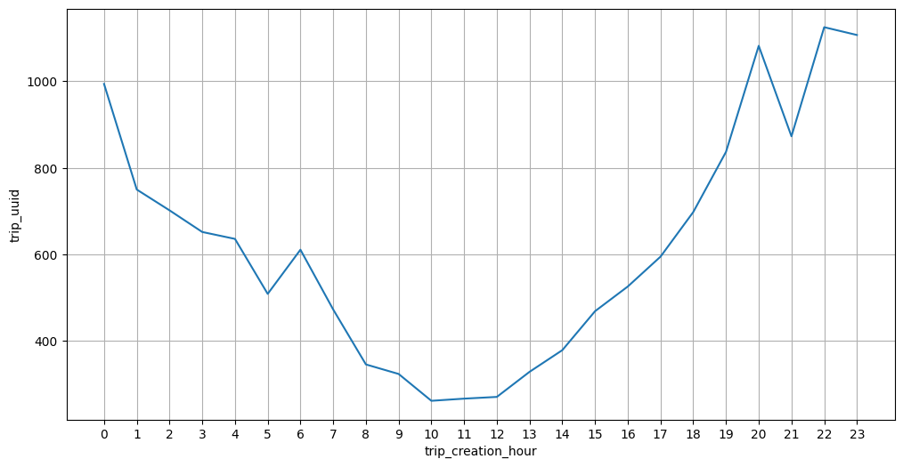

```python
plt.figure(figsize = (12, 6))
sns.lineplot(data = df_hour,
             x = df_hour['trip_creation_hour'],
             y = df_hour['trip_uuid'],
             markers = '*')
plt.xticks(np.arange(0,24))
plt.grid('both')
plt.plot()
```

```python
delhivery_df_group_tripid['trip_creation_day'].unique()
```

```
array([12, 13, 14, 15, 16, 17, 18, 19, 20, 21, 22, 23, 24, 25, 26, 27, 28,
       29, 30,  1,  2,  3], dtype=int8)
```

```python
df_day = delhivery_df_group_tripid.groupby(by = 'trip_creation_day')['trip_uuid'].count().to_frame().reset_index()
df_day.head()
```

|  | trip_creation_day | trip_uuid |
| --- | --- | --- |
| 0 | 1 | 605 |
| 1 | 2 | 552 |
| 2 | 3 | 631 |
| 3 | 12 | 747 |
| 4 | 13 | 750 |

```
[]
```

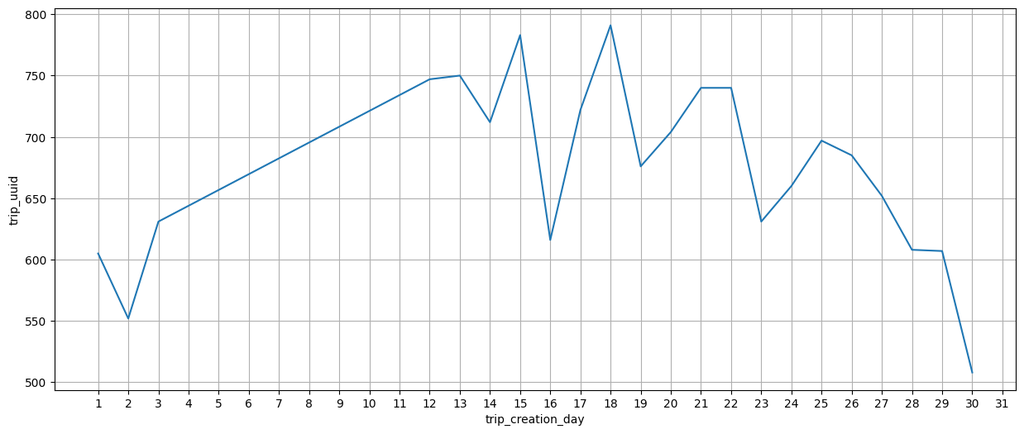

```python
plt.figure(figsize = (15, 6))
sns.lineplot(data = df_day,
             x = df_day['trip_creation_day'],
             y = df_day['trip_uuid'],
             markers = 'o')
plt.xticks(np.arange(1, 32))
plt.grid('both')
plt.plot()
```

```python
delhivery_df_group_tripid['trip_creation_week'].unique()
```

```
array([37, 38, 39, 40], dtype=int8)
```

```python
df_week = delhivery_df_group_tripid.groupby(by = 'trip_creation_week')['trip_uuid'].count().to_frame().reset_index()
df_week.head()
```

|  | trip_creation_week | trip_uuid |
| --- | --- | --- |
| 0 | 37 | 3608 |
| 1 | 38 | 5004 |
| 2 | 39 | 4417 |
| 3 | 40 | 1788 |

```
[]
```

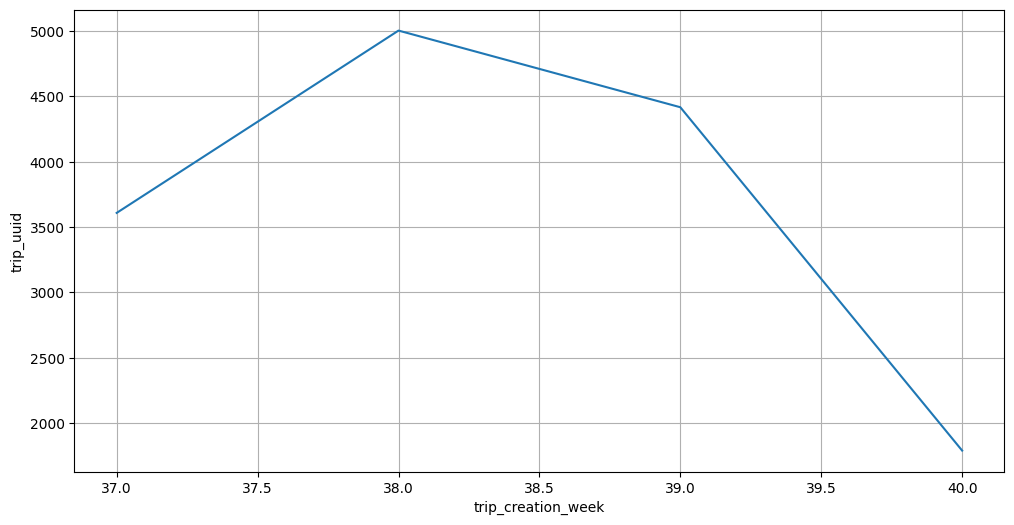

```python
plt.figure(figsize = (12, 6))
sns.lineplot(data = df_week,
             x = df_week['trip_creation_week'],
             y = df_week['trip_uuid'],
             markers = 'o')
plt.grid('both')
plt.plot()
```

```python
df_month = delhivery_df_group_tripid.groupby(by = 'trip_creation_month')['trip_uuid'].count().to_frame().reset_index()
df_month['perc'] = np.round(df_month['trip_uuid'] * 100/ df_month['trip_uuid'].sum(), 2)
df_month.head()
```

|  | trip_creation_month | trip_uuid | perc |
| --- | --- | --- | --- |
| 0 | 9 | 13029 | 87.93 |
| 1 | 10 | 1788 | 12.07 |

```
[]
```

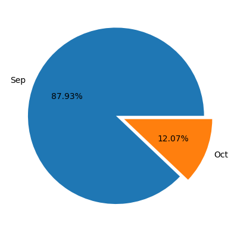

```python
plt.pie(x = df_month['trip_uuid'],
        labels = ['Sep', 'Oct'],
        explode = [0, 0.1],
       autopct = '%.2f%%')
plt.plot()
```

```python
df_data = delhivery_df_group_tripid.groupby(by = 'data')['trip_uuid'].count().to_frame().reset_index()
df_data['perc'] = np.round(df_data['trip_uuid'] * 100/ df_data['trip_uuid'].sum(), 2)
df_data.head()
```

|  | data | trip_uuid | perc |
| --- | --- | --- | --- |
| 0 | test | 4163 | 28.1 |
| 1 | training | 10654 | 71.9 |

```
[]
```

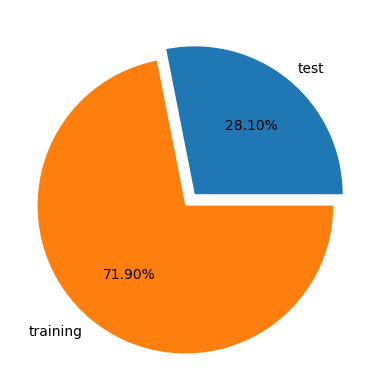

```python
plt.pie(x = df_data['trip_uuid'],
        labels = df_data['data'],
        explode = [0, 0.1],
        autopct = '%.2f%%')
plt.plot()
```

```python
df_route = delhivery_df_group_tripid.groupby(by = 'route_type')['trip_uuid'].count().to_frame().reset_index()
df_route['perc'] = np.round(df_route['trip_uuid'] * 100/ df_route['trip_uuid'].sum(), 2)
df_route.head()
```

|  | route_type | trip_uuid | perc |
| --- | --- | --- | --- |
| 0 | Carting | 8908 | 60.12 |
| 1 | FTL | 5909 | 39.88 |

```
[]
```

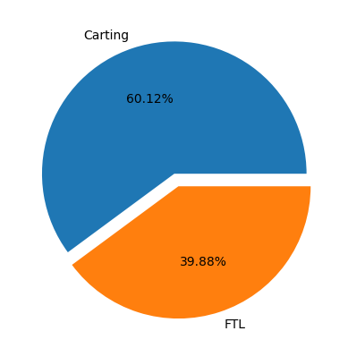

```python
plt.pie(x = df_route['trip_uuid'],
        labels = ['Carting', 'FTL'],
        explode = [0, 0.1],
        autopct = '%.2f%%')
plt.plot()
```

```python
df_source_state = delhivery_df_group_tripid.groupby(by = 'source_state')['trip_uuid'].count().to_frame().reset_index()
df_source_state['perc'] = np.round(df_source_state['trip_uuid'] * 100/ df_source_state['trip_uuid'].sum(), 2)
df_source_state = df_source_state.sort_values(by = 'trip_uuid', ascending = False)
df_source_state.head()
```

|  | source_state | trip_uuid | perc |
| --- | --- | --- | --- |
| 17 | Maharashtra | 2714 | 18.32 |
| 14 | Karnataka | 2143 | 14.46 |
| 10 | Haryana | 1838 | 12.40 |
| 24 | Tamil Nadu | 1039 | 7.01 |
| 25 | Telangana | 781 | 5.27 |

```
[]
```

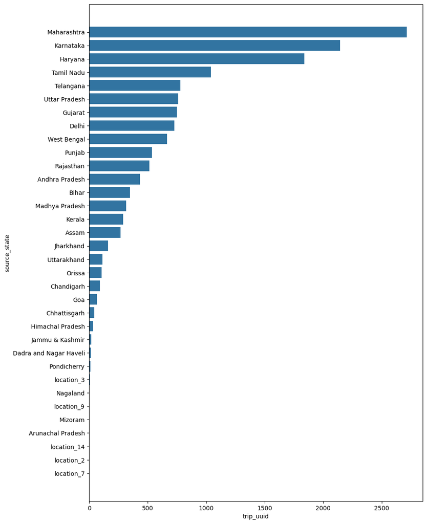

```python
plt.figure(figsize = (10, 15))
sns.barplot(data = df_source_state,
            x = df_source_state['trip_uuid'],
            y = df_source_state['source_state'])
plt.plot()
```

```python
df_source_city = delhivery_df_group_tripid.groupby(by = 'source_city')['trip_uuid'].count().to_frame().reset_index()
df_source_city['perc'] = np.round(df_source_city['trip_uuid'] * 100/ df_source_city['trip_uuid'].sum(), 2)
df_source_city = df_source_city.sort_values(by = 'trip_uuid', ascending = False)[:10]
df_source_city
```

|  | source_city | trip_uuid | perc |
| --- | --- | --- | --- |
| 439 | Mumbai | 1442 | 9.73 |
| 237 | Gurgaon | 1165 | 7.86 |
| 169 | Delhi | 883 | 5.96 |
| 79 | Bengaluru | 726 | 4.90 |
| 100 | Bhiwandi | 697 | 4.70 |
| 58 | Bangalore | 648 | 4.37 |
| 136 | Chennai | 568 | 3.83 |
| 264 | Hyderabad | 524 | 3.54 |
| 516 | Pune | 480 | 3.24 |
| 357 | Kolkata | 356 | 2.40 |

```
[]
```

[figure not shown]

```python
plt.figure(figsize = (10, 10))
sns.barplot(data = df_source_city,
            x = df_source_city['trip_uuid'],
            y = df_source_city['source_city'])
plt.plot()
```

```python
df_destination_state = delhivery_df_group_tripid.groupby(by = 'destination_state')['trip_uuid'].count().to_frame().reset_index()
df_destination_state['perc'] = np.round(df_destination_state['trip_uuid'] * 100/ df_destination_state['trip_uuid'].sum(), 2)
df_destination_state = df_destination_state.sort_values(by = 'trip_uuid', ascending = False)
df_destination_state.head()
```

|  | destination_state | trip_uuid | perc |
| --- | --- | --- | --- |
| 18 | Maharashtra | 2561 | 17.28 |
| 15 | Karnataka | 2294 | 15.48 |
| 11 | Haryana | 1643 | 11.09 |
| 25 | Tamil Nadu | 1084 | 7.32 |
| 28 | Uttar Pradesh | 811 | 5.47 |

```
[]
```

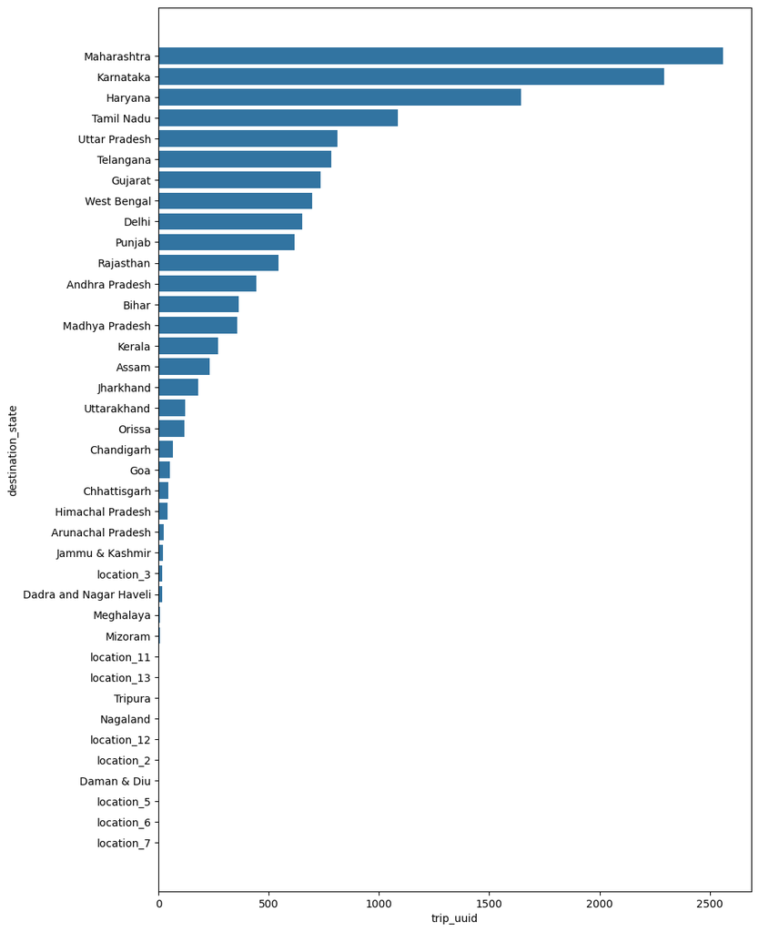

```python
plt.figure(figsize = (10, 15))
sns.barplot(data = df_destination_state,
            x = df_destination_state['trip_uuid'],
            y = df_destination_state['destination_state'])
plt.plot()
```

```python
df_destination_city = delhivery_df_group_tripid.groupby(by = 'destination_city')['trip_uuid'].count().to_frame().reset_index()
df_destination_city['perc'] = np.round(df_destination_city['trip_uuid'] * 100/ df_destination_city['trip_uuid'].sum(), 2)
df_destination_city = df_destination_city.sort_values(by = 'trip_uuid', ascending = False)[:10]
df_destination_city
```

|  | destination_city | trip_uuid | perc |
| --- | --- | --- | --- |
| 515 | Mumbai | 1548 | 10.45 |
| 96 | Bengaluru | 975 | 6.58 |
| 282 | Gurgaon | 936 | 6.32 |
| 200 | Delhi | 778 | 5.25 |
| 163 | Chennai | 595 | 4.02 |
| 72 | Bangalore | 551 | 3.72 |
| 308 | Hyderabad | 503 | 3.39 |
| 115 | Bhiwandi | 434 | 2.93 |
| 418 | Kolkata | 384 | 2.59 |
| 158 | Chandigarh | 339 | 2.29 |

```
[]
```

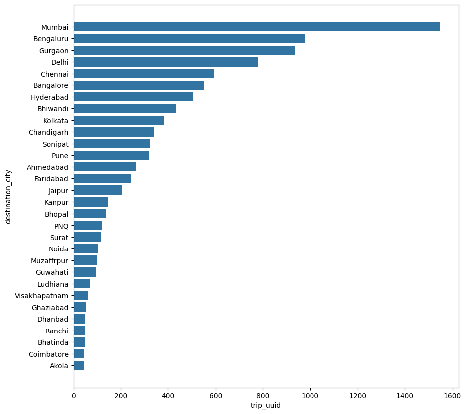

```python
plt.figure(figsize = (10, 10))
sns.barplot(data = df_destination_city,
            x = df_destination_city['trip_uuid'],
            y = df_destination_city['destination_city'])
plt.plot()
```

```
[]
```

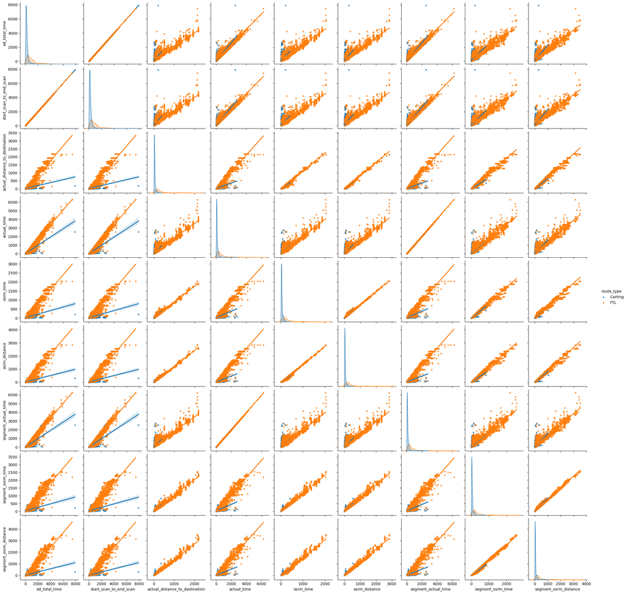

```python
numerical_columns = ['od_total_time', 'start_scan_to_end_scan', 'actual_distance_to_destination',
                    'actual_time', 'osrm_time', 'osrm_distance', 'segment_actual_time',
                    'segment_osrm_time', 'segment_osrm_distance']
sns.pairplot(data = delhivery_df_group_tripid,
             vars = numerical_columns,
             kind = 'reg',
             hue = 'route_type',
             markers = '.')
plt.plot()
```

```python
df_corr = delhivery_df_group_tripid[numerical_columns].corr()
df_corr
```

|  | od_total_time | start_scan_to_end_scan | actual_distance_to_destination | actual_time | osrm_time | osrm_distance | segment_actual_time | segment_osrm_time | segment_osrm_distance |
| --- | --- | --- | --- | --- | --- | --- | --- | --- | --- |
| od_total_time | 1.000000 | 0.999999 | 0.918222 | 0.961094 | 0.926516 | 0.924219 | 0.961119 | 0.918490 | 0.919199 |
| start_scan_to_end_scan | 0.999999 | 1.000000 | 0.918308 | 0.961147 | 0.926571 | 0.924299 | 0.961171 | 0.918561 | 0.919291 |
| actual_distance_to_destination | 0.918222 | 0.918308 | 1.000000 | 0.953757 | 0.993561 | 0.997264 | 0.952821 | 0.987538 | 0.993061 |
| actual_time | 0.961094 | 0.961147 | 0.953757 | 1.000000 | 0.958593 | 0.959214 | 0.999989 | 0.953872 | 0.956967 |
| osrm_time | 0.926516 | 0.926571 | 0.993561 | 0.958593 | 1.000000 | 0.997580 | 0.957765 | 0.993259 | 0.991608 |
| osrm_distance | 0.924219 | 0.924299 | 0.997264 | 0.959214 | 0.997580 | 1.000000 | 0.958353 | 0.991798 | 0.994710 |
| segment_actual_time | 0.961119 | 0.961171 | 0.952821 | 0.999989 | 0.957765 | 0.958353 | 1.000000 | 0.953039 | 0.956106 |
| segment_osrm_time | 0.918490 | 0.918561 | 0.987538 | 0.953872 | 0.993259 | 0.991798 | 0.953039 | 1.000000 | 0.996092 |
| segment_osrm_distance | 0.919199 | 0.919291 | 0.993061 | 0.956967 | 0.991608 | 0.994710 | 0.956106 | 0.996092 | 1.000000 |

```
[]
```

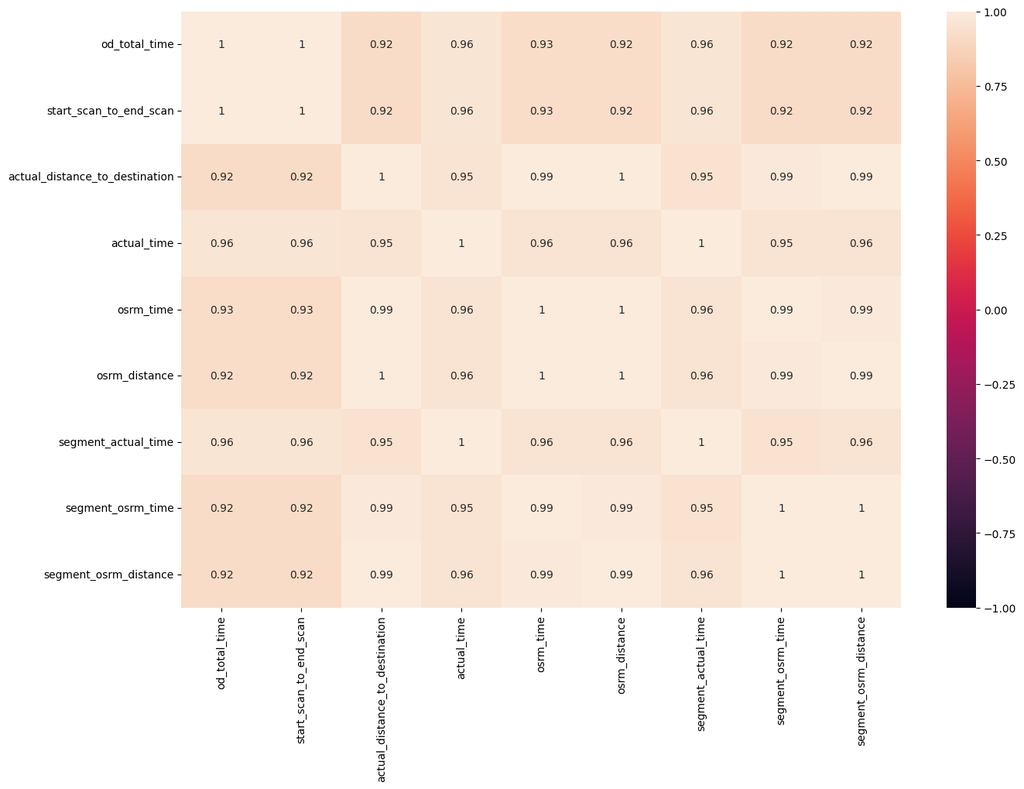

```python
plt.figure(figsize = (15, 10))
sns.heatmap(data = df_corr, vmin = -1, vmax = 1, annot = True)
plt.plot()
```

# In-depth analysis and feature engineering:

# Compare the difference between od_total_time and start_scan_to_end_scan. Do hypothesis testing/ Visual analysis to check.

```python
delhivery_df_group_tripid[['od_total_time', 'start_scan_to_end_scan']].describe()
```

|  | od_total_time | start_scan_to_end_scan |
| --- | --- | --- |
| count | 14817.000000 | 14817.000000 |
| mean | 531.697630 | 530.810016 |
| std | 658.868223 | 658.705957 |
| min | 23.460000 | 23.000000 |
| 25% | 149.930000 | 149.000000 |
| 50% | 280.770000 | 280.000000 |
| 75% | 638.200000 | 637.000000 |
| max | 7898.550000 | 7898.000000 |

```
[]
```

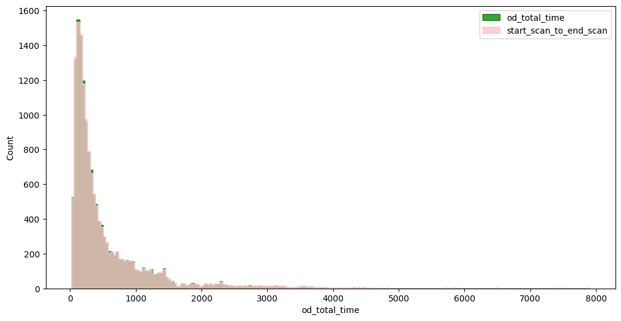

```python
plt.figure(figsize = (12, 6))
sns.histplot(delhivery_df_group_tripid['od_total_time'], element = 'step', color = 'green')
sns.histplot(delhivery_df_group_tripid['start_scan_to_end_scan'], element = 'step', color = 'pink')
plt.legend(['od_total_time', 'start_scan_to_end_scan'])
plt.plot()
```

```
[]
```

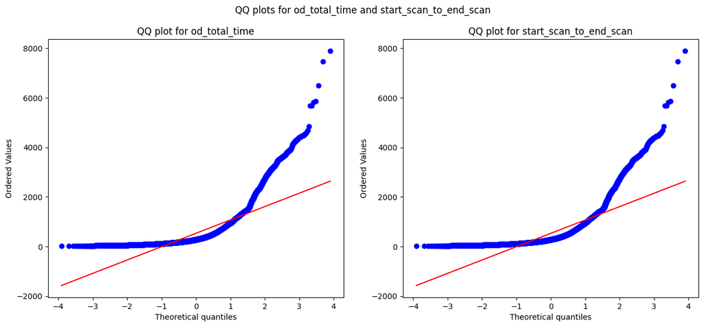

```python
plt.figure(figsize = (15, 6))
plt.subplot(1, 2, 1)
plt.suptitle('QQ plots for od_total_time and start_scan_to_end_scan')
spy.probplot(delhivery_df_group_tripid['od_total_time'], plot = plt, dist = 'norm')
plt.title('QQ plot for od_total_time')
plt.subplot(1, 2, 2)
spy.probplot(delhivery_df_group_tripid['start_scan_to_end_scan'], plot = plt, dist = 'norm')
plt.title('QQ plot for start_scan_to_end_scan')
plt.plot()
```

### Shapiro Wilk test for normality

```python
test_stat, p_value = spy.shapiro(delhivery_df_group_tripid['od_total_time'].sample(5000))
print('p-value', p_value)
if p_value < 0.05:
    print('The sample does not follow normal distribution')
else:
    print('The sample follows normal distribution')
```

```
p-value 4.484091067559512e-71
The sample does not follow normal distribution
```

```python
test_stat, p_value = spy.shapiro(delhivery_df_group_tripid['start_scan_to_end_scan'].sample(5000))
print('p-value', p_value)
if p_value < 0.05:
    print('The sample does not follow normal distribution')
else:
    print('The sample follows normal distribution')
```

```
p-value 8.002172328705407e-71
The sample does not follow normal distribution
```

## Transforming the data using boxcox transformation to check if the transformed data follows normal distribution.

```python
transformed_od_total_time = spy.boxcox(delhivery_df_group_tripid['od_total_time'])[0]
test_stat, p_value = spy.shapiro(transformed_od_total_time)
print('p-value', p_value)
if p_value < 0.05:
    print('The sample does not follow normal distribution')
else:
    print('The sample follows normal distribution')
```

```
p-value 7.500452011421218e-25
The sample does not follow normal distribution
```

```python
transformed_start_scan_to_end_scan = spy.boxcox(delhivery_df_group_tripid['start_scan_to_end_scan'])[0]
test_stat, p_value = spy.shapiro(transformed_start_scan_to_end_scan)
print('p-value', p_value)
if p_value < 0.05:
    print('The sample does not follow normal distribution')
else:
    print('The sample follows normal distribution')
```

```
p-value 1.0563374658310944e-24
The sample does not follow normal distribution
```

## Trying Lavene's test for Homogenity

```python
# Null Hypothesis(H0) - Homogenous Variance

# Alternate Hypothesis(HA) - Non Homogenous Variance

test_stat, p_value = spy.levene(delhivery_df_group_tripid['od_total_time'], delhivery_df_group_tripid['start_scan_to_end_scan'])
print('p-value', p_value)
if p_value < 0.05:
    print('The samples do not have  Homogenous Variance')
else:
    print('The samples have Homogenous Variance ')
```

```
p-value 0.9668007217581142
The samples have Homogenous Variance
```

## Since the samples are not normally distributed, T-Test cannot be applied here, we can perform its non parametric equivalent test i.e., Mann-Whitney U rank test for two independent samples.

```python
test_stat, p_value = spy.mannwhitneyu(delhivery_df_group_tripid['od_total_time'], delhivery_df_group_tripid['start_scan_to_end_scan'])
print('P-value :',p_value)
```

```
P-value : 0.7815123224221716
```

## Observation:

Since p-value > alpha therfore it can be concluded that od_total_time and start_scan_to_end_scan are similar.

```python
delhivery_df_group_tripid[['osrm_time', 'segment_osrm_time']].describe().T
```

|  | count | mean | std | min | 25% | 50% | 75% | max |
| --- | --- | --- | --- | --- | --- | --- | --- | --- |
| osrm_time | 14817.0 | 161.384018 | 271.360992 | 6.0 | 29.0 | 60.0 | 168.0 | 2032.0 |
| segment_osrm_time | 14817.0 | 180.949783 | 314.542053 | 6.0 | 31.0 | 65.0 | 185.0 | 2564.0 |

```
[]
```

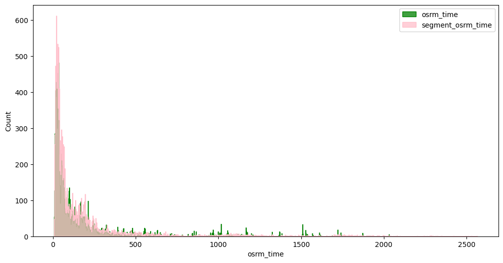

```python
plt.figure(figsize = (12, 6))
sns.histplot(delhivery_df_group_tripid['osrm_time'], element = 'step', color = 'green', bins = 1000)
sns.histplot(delhivery_df_group_tripid['segment_osrm_time'], element = 'step', color = 'pink', bins = 1000)
plt.legend(['osrm_time', 'segment_osrm_time'])
plt.plot()
```

```
[]
```

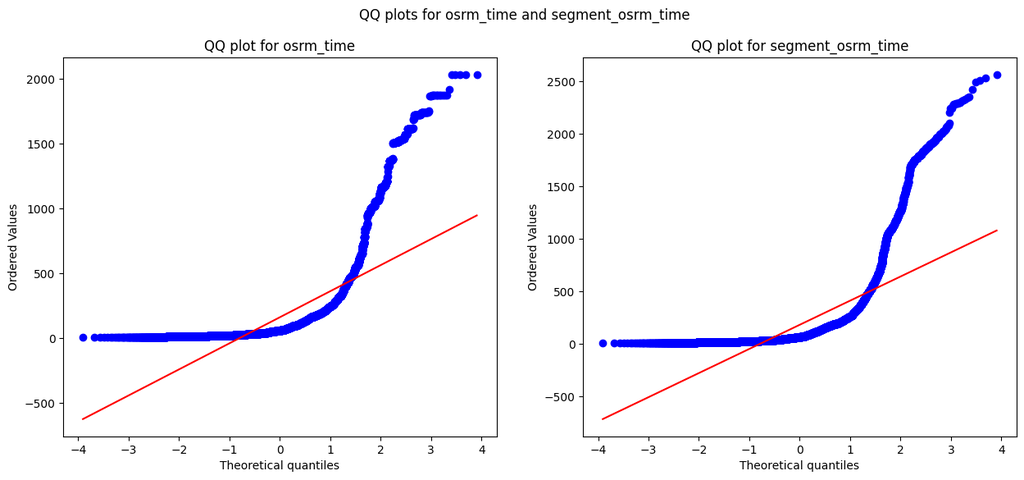

```python
plt.figure(figsize = (15, 6))
plt.subplot(1, 2, 1)
plt.suptitle('QQ plots for osrm_time and segment_osrm_time')
spy.probplot(delhivery_df_group_tripid['osrm_time'], plot = plt, dist = 'norm')
plt.title('QQ plot for osrm_time')
plt.subplot(1, 2, 2)
spy.probplot(delhivery_df_group_tripid['segment_osrm_time'], plot = plt, dist = 'norm')
plt.title('QQ plot for segment_osrm_time')
plt.plot()
```

### Shapiro Wilk Test

```python
test_stat, p_value = spy.shapiro(delhivery_df_group_tripid['osrm_time'].sample(5000))
print('p-value', p_value)
if p_value < 0.05:
    print('The sample does not follow normal distribution')
else:
    print('The sample follows normal distribution')
```

```
p-value 4.227432278752191e-78
The sample does not follow normal distribution
```

```python
test_stat, p_value = spy.shapiro(delhivery_df_group_tripid['segment_osrm_time'].sample(5000))
print('p-value', p_value)
if p_value < 0.05:
    print('The sample does not follow normal distribution')
else:
    print('The sample follows normal distribution')
```

```
p-value 1.1695803690406712e-78
The sample does not follow normal distribution
```

```python
transformed_osrm_time = spy.boxcox(delhivery_df_group_tripid['osrm_time'])[0]
test_stat, p_value = spy.shapiro(transformed_osrm_time)
print('p-value', p_value)
if p_value < 0.05:
    print('The sample does not follow normal distribution')
else:
    print('The sample follows normal distribution')
```

```
p-value 3.5114710538974565e-35
The sample does not follow normal distribution
```

```python
transformed_segment_osrm_time = spy.boxcox(delhivery_df_group_tripid['segment_osrm_time'])[0]
test_stat, p_value = spy.shapiro(transformed_segment_osrm_time)
print('p-value', p_value)
if p_value < 0.05:
    print('The sample does not follow normal distribution')
else:
    print('The sample follows normal distribution')
```

```
p-value 4.880441318638605e-34
The sample does not follow normal distribution
```

### Lavene's test

```python
# Null Hypothesis(H0) - Homogenous Variance

# Alternate Hypothesis(HA) - Non Homogenous Variance

test_stat, p_value = spy.levene(delhivery_df_group_tripid['osrm_time'], delhivery_df_group_tripid['segment_osrm_time'])
print('p-value', p_value)

if p_value < 0.05:
    print('The samples do not have Homogenous Variance')
else:
    print('The samples have Homogenous Variance ')
```

```
p-value 8.349506135727595e-08
The samples do not have Homogenous Variance
```

```python
test_stat, p_value = spy.mannwhitneyu(delhivery_df_group_tripid['osrm_time'], delhivery_df_group_tripid['segment_osrm_time'])
print('p-value', p_value)
if p_value < 0.05:
    print('The samples are not similar')
else:
    print('The samples are similar ')
```

```
p-value 2.2995370859748865e-08
The samples are not similar
```

Find outliers in the numerical variables (you might find outliers in almost all the variables), and check it using visual analysis

```python
numerical_columns = ['od_total_time', 'start_scan_to_end_scan', 'actual_distance_to_destination',
                    'actual_time', 'osrm_time', 'osrm_distance', 'segment_actual_time',
                    'segment_osrm_time', 'segment_osrm_distance']
delhivery_df_group_tripid[numerical_columns].describe().T
```

|  | count | mean | std | min | 25% | 50% | 75% | max |
| --- | --- | --- | --- | --- | --- | --- | --- | --- |
| od_total_time | 14817.0 | 531.697630 | 658.868223 | 23.460000 | 149.930000 | 280.770000 | 638.200000 | 7898.550000 |
| start_scan_to_end_scan | 14817.0 | 530.810016 | 658.705957 | 23.000000 | 149.000000 | 280.000000 | 637.000000 | 7898.000000 |
| actual_distance_to_destination | 14817.0 | 164.477829 | 305.388153 | 9.002461 | 22.837238 | 48.474072 | 164.583206 | 2186.531738 |
| actual_time | 14817.0 | 357.143768 | 561.396118 | 9.000000 | 67.000000 | 149.000000 | 370.000000 | 6265.000000 |
| osrm_time | 14817.0 | 161.384018 | 271.360992 | 6.000000 | 29.000000 | 60.000000 | 168.000000 | 2032.000000 |
| osrm_distance | 14817.0 | 204.344711 | 370.395569 | 9.072900 | 30.819201 | 65.618805 | 208.475006 | 2840.081055 |
| segment_actual_time | 14817.0 | 353.892273 | 556.247925 | 9.000000 | 66.000000 | 147.000000 | 367.000000 | 6230.000000 |
| segment_osrm_time | 14817.0 | 180.949783 | 314.542053 | 6.000000 | 31.000000 | 65.000000 | 185.000000 | 2564.000000 |
| segment_osrm_distance | 14817.0 | 223.201157 | 416.628387 | 9.072900 | 32.654499 | 70.154404 | 218.802399 | 3523.632324 |

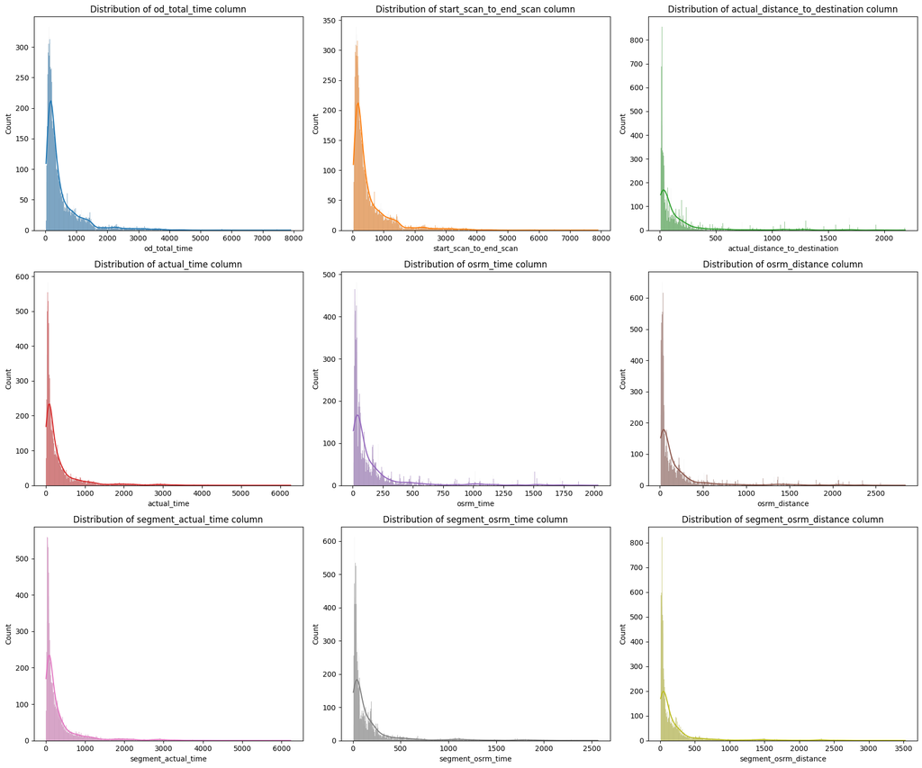

```python
plt.figure(figsize=(18, 15))
colors = plt.get_cmap('tab10').colors

for i in range(len(numerical_columns)):
    plt.subplot(3, 3, i + 1)
    clr = colors[i % len(colors)]
    sns.histplot(delhivery_df_group_tripid[numerical_columns[i]], bins=1000, kde=True, color=clr)
    plt.title(f"Distribution of {numerical_columns[i]} column")

plt.tight_layout()
plt.show()
```

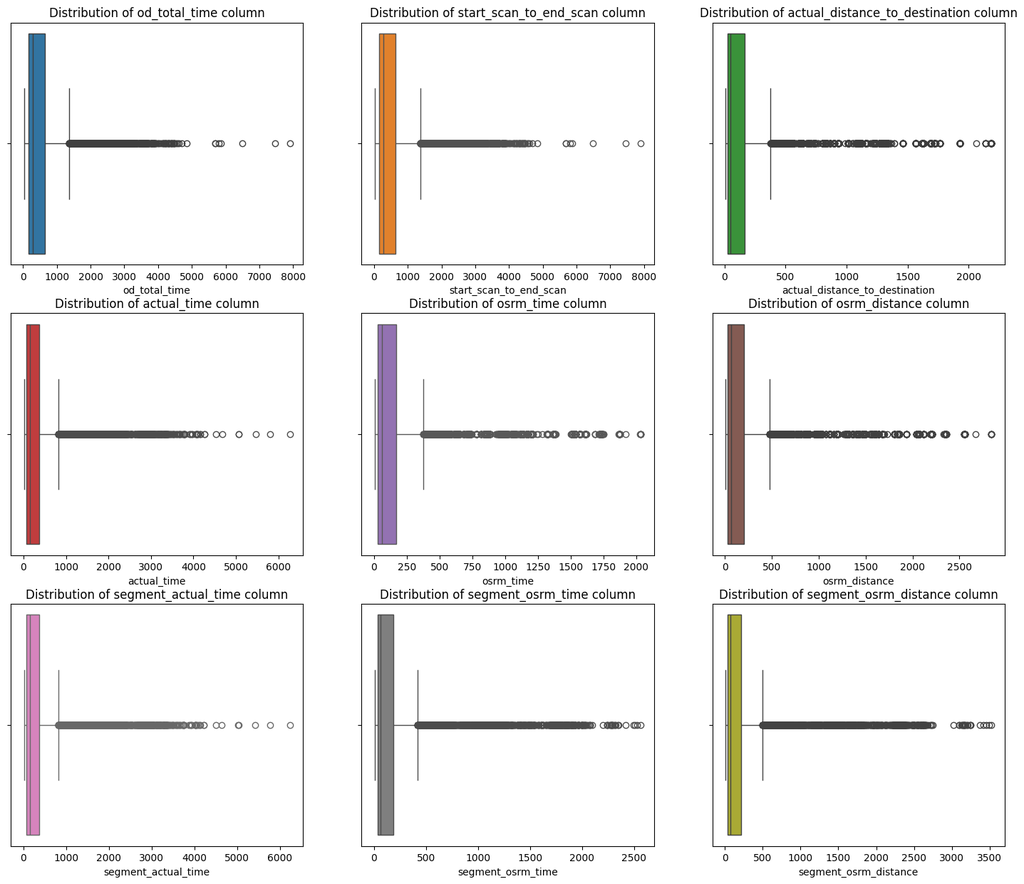

```python
plt.figure(figsize = (18, 15))
colors = plt.get_cmap('tab10').colors
for i in range(len(numerical_columns)):
    plt.subplot(3, 3, i + 1)
    clr = colors[i % len(colors)]
    sns.boxplot(x=delhivery_df_group_tripid[numerical_columns[i]], color = clr)
    plt.title(f"Distribution of {numerical_columns[i]} column")
    plt.plot()
```

```python
# Detecting Outliers

for i in numerical_columns:
    Q1 = np.quantile(delhivery_df_group_tripid[i], 0.25)
    Q3 = np.quantile(delhivery_df_group_tripid[i], 0.75)
    IQR = Q3 - Q1
    LB = Q1 - 1.5 * IQR
    UB = Q3 + 1.5 * IQR
    outliers = delhivery_df_group_tripid.loc[(delhivery_df_group_tripid[i] < LB) | (delhivery_df_group_tripid[i] > UB)]
    print('Column :', i)
    print(f'Q1 : {Q1}')
    print(f'Q3 : {Q3}')
    print(f'IQR : {IQR}')
    print(f'LB : {LB}')
    print(f'UB : {UB}')
    print(f'Number of outliers : {outliers.shape[0]}')
    print('----------------------------------')
```

```
Column : od_total_time
Q1 : 149.93
Q3 : 638.2
IQR : 488.27000000000004
LB : -582.4750000000001
UB : 1370.605
Number of outliers : 1266
----------------------------------
Column : start_scan_to_end_scan
Q1 : 149.0
Q3 : 637.0
IQR : 488.0
LB : -583.0
UB : 1369.0
Number of outliers : 1267
----------------------------------
Column : actual_distance_to_destination
Q1 : 22.837238311767578
Q3 : 164.5832061767578
IQR : 141.74596786499023
LB : -189.78171348571777
UB : 377.20215797424316
Number of outliers : 1449
----------------------------------
Column : actual_time
Q1 : 67.0
Q3 : 370.0
IQR : 303.0
LB : -387.5
UB : 824.5
Number of outliers : 1643
----------------------------------
Column : osrm_time
Q1 : 29.0
Q3 : 168.0
IQR : 139.0
LB : -179.5
UB : 376.5
Number of outliers : 1517
----------------------------------
```

[output cut: 17 more lines]

```
Q1 : 31.0
Q3 : 185.0
IQR : 154.0
LB : -200.0
UB : 416.0
Number of outliers : 1492
----------------------------------
Column : segment_osrm_distance
Q1 : 32.65449905395508
Q3 : 218.80239868164062
IQR : 186.14789962768555
LB : -246.56735038757324
UB : 498.02424812316895
Number of outliers : 1548
----------------------------------
```

### Do one-hot encoding of categorical variables (like route_type)

```python
# Get value counts before one-hot encoding

delhivery_df_group_tripid['route_type'].value_counts()
```

```
route_type
Carting    8908
FTL        5909
Name: count, dtype: int64
```

```python
from sklearn.preprocessing import LabelEncoder
label_encoder = LabelEncoder()
delhivery_df_group_tripid['route_type'] = label_encoder.fit_transform(delhivery_df_group_tripid['route_type'])
```

```python
# Get value counts after one-hot encoding

delhivery_df_group_tripid['route_type'].value_counts()
```

```
route_type
0    8908
1    5909
Name: count, dtype: int64
```

```python
# Get value counts of categorical variable 'data' before one-hot encoding

delhivery_df_group_tripid['data'].value_counts()
```

```
data
training    10654
test         4163
Name: count, dtype: int64
```

```python
label_encoder = LabelEncoder()
delhivery_df_group_tripid['data'] = label_encoder.fit_transform(delhivery_df_group_tripid['data'])
```

```python
delhivery_df_group_tripid['data'].value_counts()
```

```
data
1    10654
0     4163
Name: count, dtype: int64
```

### Normalize/ Standardize the numerical features using MinMaxScaler or StandardScaler.

```python
from sklearn.preprocessing import MinMaxScaler
```

```
[]
```

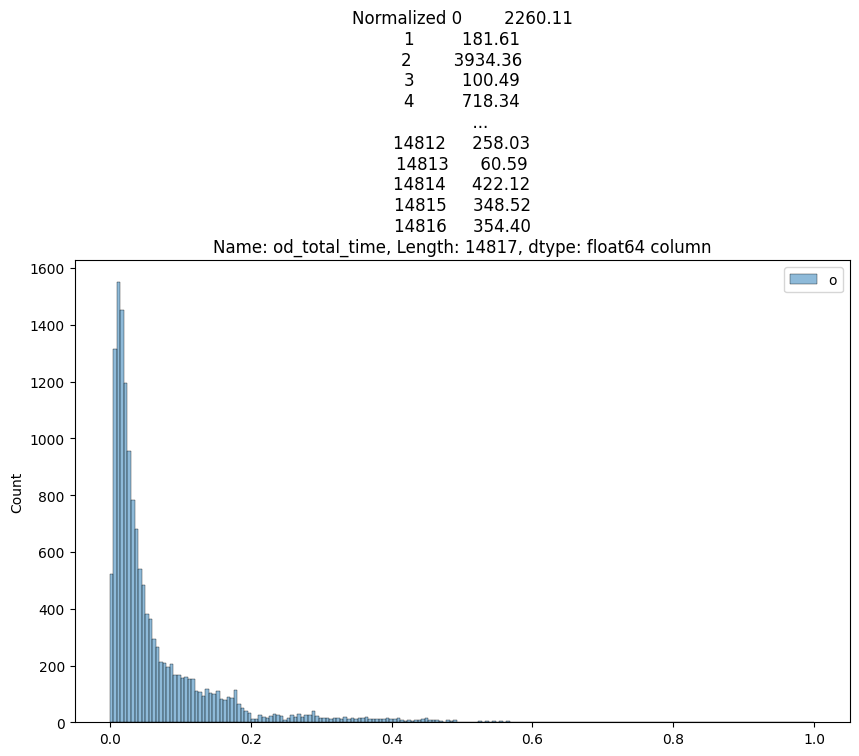

```python
plt.figure(figsize = (10, 6))
scaler = MinMaxScaler()
scaled = scaler.fit_transform(delhivery_df_group_tripid['od_total_time'].to_numpy().reshape(-1, 1))
sns.histplot(scaled)
plt.title(f"Normalized {delhivery_df_group_tripid['od_total_time']} column")
plt.legend('od_total_time')
plt.plot()
```

```
[]
```

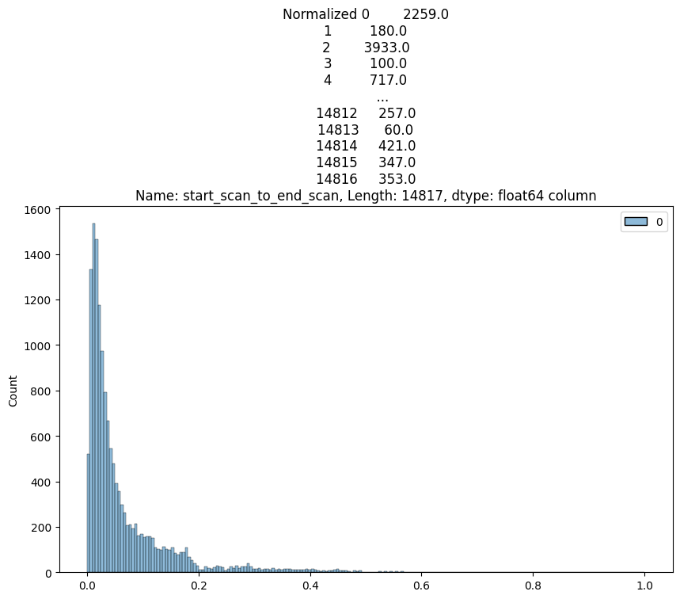

```python
plt.figure(figsize = (10, 6))
scaler = MinMaxScaler()
scaled = scaler.fit_transform(delhivery_df_group_tripid['start_scan_to_end_scan'].to_numpy().reshape(-1, 1))
sns.histplot(scaled)
plt.title(f"Normalized {delhivery_df_group_tripid['start_scan_to_end_scan']} column")
plt.plot()
```

```
[]
```

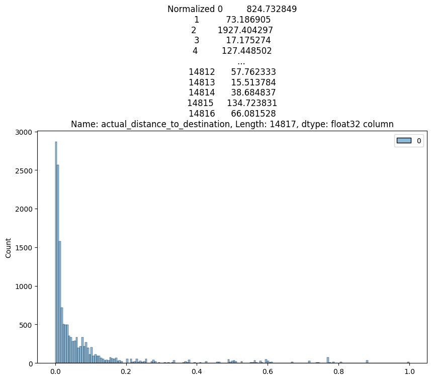

```python
plt.figure(figsize = (10, 6))
scaler = MinMaxScaler()
scaled = scaler.fit_transform(delhivery_df_group_tripid['actual_distance_to_destination'].to_numpy().reshape(-1, 1))
sns.histplot(scaled)
plt.title(f"Normalized {delhivery_df_group_tripid['actual_distance_to_destination']} column")
plt.plot()
```

```
[]
```

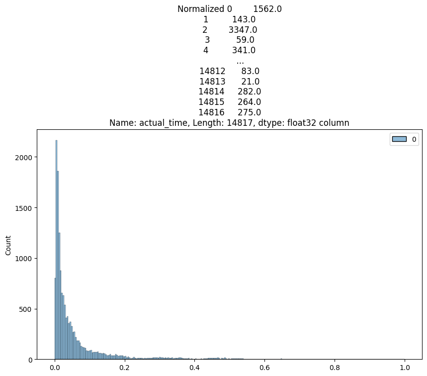

```python
plt.figure(figsize = (10, 6))
scaler = MinMaxScaler()
scaled = scaler.fit_transform(delhivery_df_group_tripid['actual_time'].to_numpy().reshape(-1, 1))
sns.histplot(scaled)
plt.title(f"Normalized {delhivery_df_group_tripid['actual_time']} column")
plt.plot()
```